# Фильтр пакетов

Майоров Дмитрий Андреевич

# Информация

## Докладчик

- Майоров Дмитрий Андреевич

# Цель работы

Получить навыки настройки пакетного фильтра в Linux.

# Выполнение лабораторной работы

Определяем текущую зону по умолчанию. Определяем доступные зоны. Смотрим службы, доступные на нашем компьютере

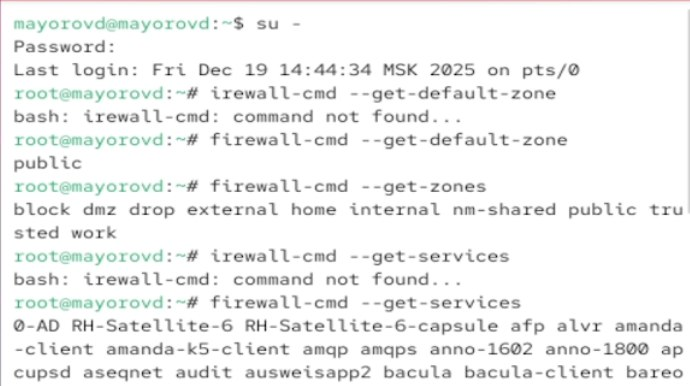

Рисунок 1

# Выполнение лабораторной работы

Определяем доступные службы в текущей зоне

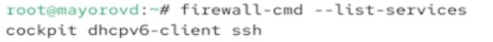

Рисунок 2

# Выполнение лабораторной работы

Вводим две команды для вывода информации. Первая команда выводит информацию для активной зоны, а вторая тольок для указанной

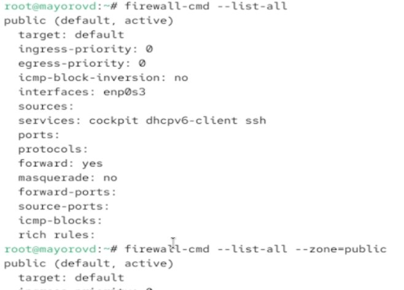

Рисунок 3

# Выполнение лабораторной работы

Добавляем сервер VNS в конфигурацию брэндмауэра. Проверяем, добавился ли он

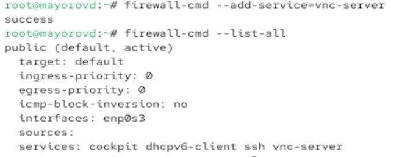

Рисунок 4

# Выполнение лабораторной работы

Перезапускаем службу firewall. Проверяем есть ли в конфигурации vns-сервер. Его нет, так как он был добавлен временным правилом(без permanent)

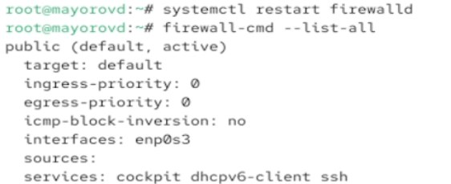

Рисунок 5

# Выполнение лабораторной работы

Еще раз добавляем сервер, но уже делаем его постоянным. Проверяем, добавился ли он

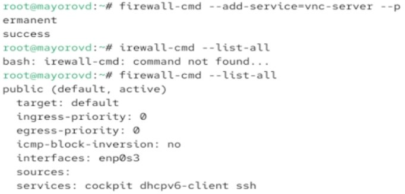

Рисунок 6

# Выполнение лабораторной работы

Перезагружаем конфигурацию firewalld и смотрим конфигурацию времени выполнения

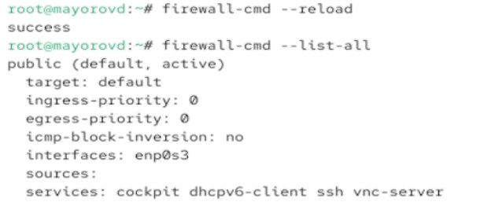

Рисунок 7

# Выполнение лабораторной работы

Добавляем в конфигурацию межсетевого экрана порт 2022 протокола TCP. Перезагружаем конфигурацию. Проверяем, добавился ли порт

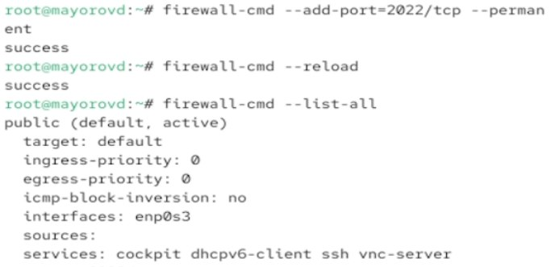

Рисунок 8

# Выполнение лабораторной работы

Устанавливаем firewall-config.

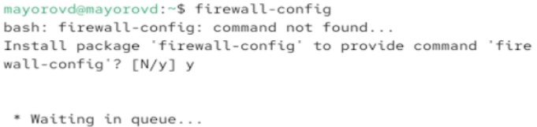

Рисунок 9

# Выполнение лабораторной работы

Нажимаем выпадающее меню рядом с параметром Configuration . Открываем раскрывающийся список выберираем Permanent. Выбераем зону public и отмечаем службы http, https и ftp, чтобы включить их.

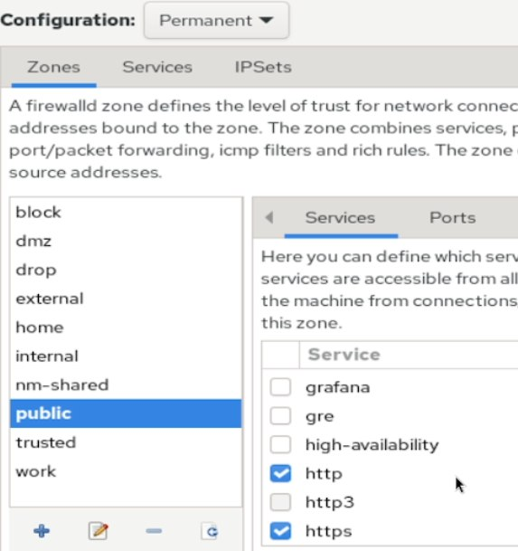

Рисунок 10

# Выполнение лабораторной работы

Выбераем вкладку Ports и на этой вкладке нажимаем Add . Вводим порт 2022 и протокол udp.

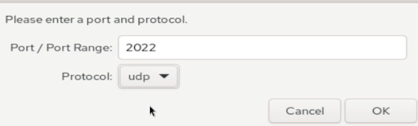

Рисунок 11

# Выполнение лабораторной работы

Вводим команду firewall-cmd –list-all.

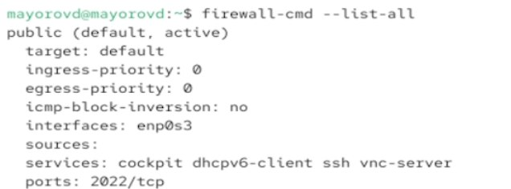

Рисунок 12

# Выполнение лабораторной работы

Изменения которые мы внесли еще не вступили в силу. Перезагружаем конфигурацию. Снова смотрим список доступных сервисов.

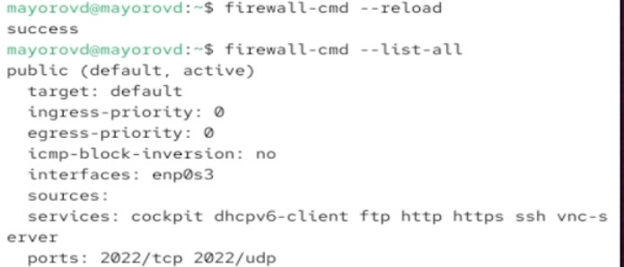

Рисунок 13

# Выполнение лабораторной работы

Добавляем вручную службу telnet в постоянную конфинурацию

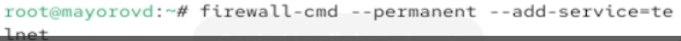

Рисунок 14

# Выполнение лабораторной работы

В графическом интерфейсе добавляем остальные нужные нам службы

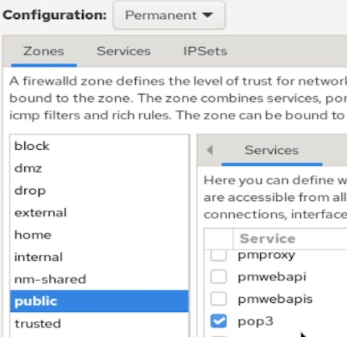

Рисунок 15

# Выполнение лабораторной работы

Выбераем вкладку Ports и на этой вкладке нажимаем Add . Вводим порт 2022 и протокол udp.

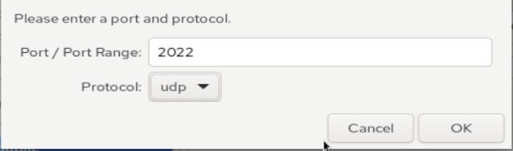

Рисунок 16

# Выполнение лабораторной работы

Перезагружаем конфигурацию. Смотрим список доступных сервисов.

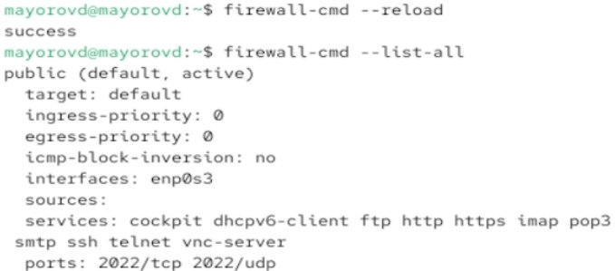

Рисунок 17

# Выполнение лабораторной работы

# Выводы

Получены навыки настройки пакетного фильтра в Linux.